# Churn Modeling using ANN

```python
# Importing the libraries
import numpy as np
import matplotlib.pyplot as plt
import pandas as pd
import keras
```

```python
# Importing the churn dataset
dataset = pd.read_csv("Churn_Modelling.csv")
X = dataset.iloc[:, 3:13].values
y = dataset.iloc[:, 13].values
```

```python
dataset.head()
```

|  | RowNumber | CustomerId | Surname | CreditScore | Geography | Gender | Age | Tenure | Balance | NumOfProducts | HasCrCard | IsActiveMember | EstimatedSalary | Exited |
| --- | --- | --- | --- | --- | --- | --- | --- | --- | --- | --- | --- | --- | --- | --- |
| 0 | 1 | 15634602 | Hargrave | 619 | France | Female | 42 | 2 | 0.00 | 1 | 1 | 1 | 101348.88 | 1 |
| 1 | 2 | 15647311 | Hill | 608 | Spain | Female | 41 | 1 | 83807.86 | 1 | 0 | 1 | 112542.58 | 0 |
| 2 | 3 | 15619304 | Onio | 502 | France | Female | 42 | 8 | 159660.80 | 3 | 1 | 0 | 113931.57 | 1 |
| 3 | 4 | 15701354 | Boni | 699 | France | Female | 39 | 1 | 0.00 | 2 | 0 | 0 | 93826.63 | 0 |
| 4 | 5 | 15737888 | Mitchell | 850 | Spain | Female | 43 | 2 | 125510.82 | 1 | 1 | 1 | 79084.10 | 0 |

```python
dataset.dtypes
```

```
RowNumber            int64
CustomerId           int64
Surname             object
CreditScore          int64
Geography           object
Gender              object
Age                  int64
Tenure               int64
Balance            float64
NumOfProducts        int64
HasCrCard            int64
IsActiveMember       int64
EstimatedSalary    float64
Exited               int64
dtype: object
```

```python
dataset.describe()
```

|  | RowNumber | CustomerId | CreditScore | Age | Tenure | Balance | NumOfProducts | HasCrCard | IsActiveMember | EstimatedSalary | Exited |
| --- | --- | --- | --- | --- | --- | --- | --- | --- | --- | --- | --- |
| count | 10000.00000 | 1.000000e+04 | 10000.000000 | 10000.000000 | 10000.000000 | 10000.000000 | 10000.000000 | 10000.00000 | 10000.000000 | 10000.000000 | 10000.000000 |
| mean | 5000.50000 | 1.569094e+07 | 650.528800 | 38.921800 | 5.012800 | 76485.889288 | 1.530200 | 0.70550 | 0.515100 | 100090.239881 | 0.203700 |
| std | 2886.89568 | 7.193619e+04 | 96.653299 | 10.487806 | 2.892174 | 62397.405202 | 0.581654 | 0.45584 | 0.499797 | 57510.492818 | 0.402769 |
| min | 1.00000 | 1.556570e+07 | 350.000000 | 18.000000 | 0.000000 | 0.000000 | 1.000000 | 0.00000 | 0.000000 | 11.580000 | 0.000000 |
| 25% | 2500.75000 | 1.562853e+07 | 584.000000 | 32.000000 | 3.000000 | 0.000000 | 1.000000 | 0.00000 | 0.000000 | 51002.110000 | 0.000000 |
| 50% | 5000.50000 | 1.569074e+07 | 652.000000 | 37.000000 | 5.000000 | 97198.540000 | 1.000000 | 1.00000 | 1.000000 | 100193.915000 | 0.000000 |
| 75% | 7500.25000 | 1.575323e+07 | 718.000000 | 44.000000 | 7.000000 | 127644.240000 | 2.000000 | 1.00000 | 1.000000 | 149388.247500 | 0.000000 |
| max | 10000.00000 | 1.581569e+07 | 850.000000 | 92.000000 | 10.000000 | 250898.090000 | 4.000000 | 1.00000 | 1.000000 | 199992.480000 | 1.000000 |

```python
dataset.apply(lambda x: sum(x.isnull().values),axis=0)
```

```
RowNumber          0
CustomerId         0
Surname            0
CreditScore        0
Geography          0
Gender             0
Age                0
Tenure             0
Balance            0
NumOfProducts      0
HasCrCard          0
IsActiveMember     0
EstimatedSalary    0
Exited             0
dtype: int64
```

Looks like the dataset does not contain any missing values.

Out of the variables of importance, 2 are categorical (Geography and Gender) Let us first label encode these categorical variables. Let us take a look at the independent variables

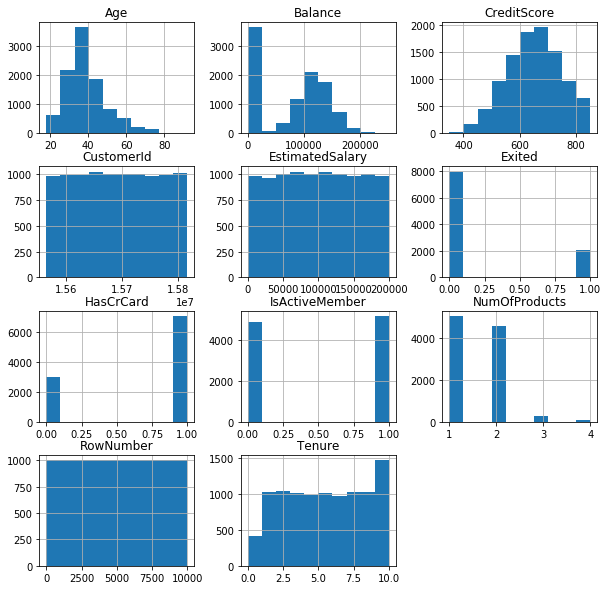

```python
dataset.hist(figsize=(10,10))
plt.show()
```

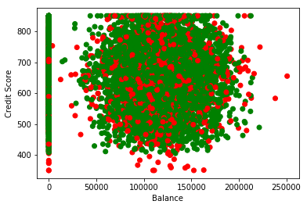

```python
col = ['red' if label ==1 else 'green' for label in dataset['Exited']]
plt.scatter(x=dataset['Balance'],y=dataset["CreditScore"],color=col)
plt.xlabel("Balance")
plt.ylabel("Credit Score")
plt.show()
```

Balance and Credit Score Scatter plot does not show any peculiar patterns

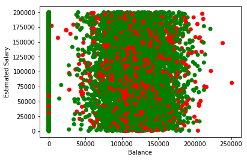

```python
plt.scatter(x=dataset['Balance'],y=dataset["EstimatedSalary"],color=col)
plt.xlabel("Balance")
plt.ylabel("Estimated Salary")
plt.show()
```

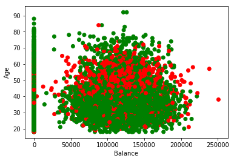

```python
plt.scatter(x=dataset['Balance'],y=dataset["Age"],color=col)
plt.xlabel("Balance")
plt.ylabel("Age")
plt.show()
```

From the above scatter plot, it seems like age has an effect on whether the customer will exit or not.

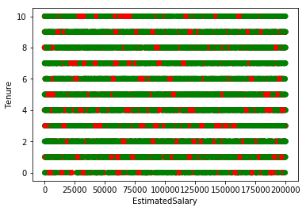

```python
plt.scatter(x=dataset['EstimatedSalary'],y=dataset["Tenure"],color=col)
plt.xlabel("EstimatedSalary")
plt.ylabel("Tenure")
plt.show()
```

```python
from sklearn.preprocessing import LabelEncoder,OneHotEncoder
labelEncoder = LabelEncoder()
X[:,1] = labelEncoder.fit_transform(X[:,1]) # Encoding Geography
X[:,2] = labelEncoder.fit_transform(X[:,2]) # Encoding Gender
```

```python
X
```

```
array([[619, 0, 0, ..., 1, 1, 101348.88],
       [608, 2, 0, ..., 0, 1, 112542.58],
       [502, 0, 0, ..., 1, 0, 113931.57],
       ...,
       [709, 0, 0, ..., 0, 1, 42085.58],
       [772, 1, 1, ..., 1, 0, 92888.52],
       [792, 0, 0, ..., 1, 0, 38190.78]], dtype=object)
```

As the categorical variable Geography is nominal (there is no order in the variable e.g Spain is not greater than France etc.) I will convert these different geographies into features with one hot encoding

```python
oneHotEncoder = OneHotEncoder(categorical_features=[1])
X_coded = oneHotEncoder.fit_transform(X).toarray()
X_coded = X_coded[:,1:] # To avoid dummy variable trap
```

```python
np.set_printoptions(precision=2,suppress=True)
print(X_coded)
```

```
[[      0.         0.       619.   ...,       1.         1.    101348.88]
 [      0.         1.       608.   ...,       0.         1.    112542.58]
 [      0.         0.       502.   ...,       1.         0.    113931.57]
 ...,
 [      0.         0.       709.   ...,       0.         1.     42085.58]
 [      1.         0.       772.   ...,       1.         0.     92888.52]
 [      0.         0.       792.   ...,       1.         0.     38190.78]]
```

Ok Looks good. Now let us split this into training and test sets.

```python
from sklearn.model_selection import train_test_split
X_train, X_test, y_train, y_test = train_test_split(X_coded,y,test_size=0.2,random_state = 0)
```

It can be noticed from the data preview above that the features have varying scales. We do not want certain features with larger scales dominating other features in the ANN. Thus feature scaling is required.

```python
from sklearn.preprocessing import StandardScaler
scale = StandardScaler()
X_train = scale.fit_transform(X_train)
X_test = scale.fit_transform(X_test)
```

Alright, the features are scaled. Now let us build an ANN for this classification task

```python
# Import Sequential and Dense package
from keras.models import Sequential
from keras.layers import Dense
from keras.layers import Dropout
```

```python
from keras.wrappers.scikit_learn import KerasClassifier
from sklearn.model_selection import cross_val_score
```

```python
def build_Classifier():
    classifier = Sequential()
    #Adding the input and the first hidden layer
    classifier.add(layer=Dense(units=6,kernel_initializer='uniform',activation='relu',input_dim=11))
    # Adding droupout - Regularization
    classifier.add(Dropout(p=0.1))
    # Adding another hidden layer
    classifier.add(layer=Dense(units=6,kernel_initializer='uniform',activation='relu'))
    classifier.add(Dropout(p=0.1))
    #Adding the output layer
    classifier.add(layer=Dense(units=1,kernel_initializer='uniform',activation='sigmoid'))
    classifier.compile(optimizer='adam',loss='binary_crossentropy',metrics=['accuracy'])
    return classifier
```

```python
classifier = KerasClassifier(build_fn=build_Classifier,batch_size = 10,nb_epoch=100)
accuracies = cross_val_score(estimator = classifier,X = X_train,y= y_train,cv= 10,n_jobs=-1)
```

```python
accuracies.mean()
```

```
0.82262499593198302
```

```python
accuracies.std()
```

```
0.013606637588803922
```

```python
from keras.wrappers.scikit_learn import KerasClassifier
from sklearn.model_selection import GridSearchCV
```

```python
def build_Classifier(optimizer):
    classifier = Sequential()
    #Adding the input and the first hidden layer
    classifier.add(layer=Dense(units=6,kernel_initializer='uniform',activation='relu',input_dim=11))
    # Adding another hidden layer
    classifier.add(layer=Dense(units=6,kernel_initializer='uniform',activation='relu'))
    #Adding the output layer
    classifier.add(layer=Dense(units=1,kernel_initializer='uniform',activation='sigmoid'))
    classifier.compile(optimizer = optimizer,loss='binary_crossentropy',metrics=['accuracy'])
    return classifier
```

Parameter Tuning

```python
classifier = KerasClassifier(build_fn=build_Classifier)
```

```python
params = {'batch_size' : [1,5,10],
          'nb_epoch' : [200,500,700],
         'optimizer' : ['adam','rmsprop']}
```

```python
gridSearch = GridSearchCV(cv = 10,
                          param_grid= params,
                          estimator = classifier,
                          scoring = "accuracy",n_jobs=-1)
```

```python
grid = gridSearch.fit(X_train,y_train)
```

```python
best_params = grid.best_params_
best_accuracy = grid.best_score_
```

```python
best_accuracy
```

```
0.84012500000000001
```

```python
best_params
```

```
{'batch_size': 10, 'nb_epoch': 200, 'optimizer': 'adam'}
```